# Assignment 6

Sreedevi Kesavan

05/03/2021

## New HIV Cases and the Mother to Child transmission rate in Africa

```r
#Packages Used ----
library(dplyr)
library(ggpubr)
library(emmeans)
```

This data has been downloaded from https://data.unicef.org/dv_index/

```r
data <- read.csv('fusion_GLOBAL_DATAFLOW_UNICEF_1.0_all.csv')
ES_Africa <- read.csv('ES_Africa.csv')
Countries <- ES_Africa[,1]
```

I used the tidyverse to clean up the relevant data from the total dataset. I have created two final tibbles for the two analyses to follow. From previous work with this dataset, we know that there are some countries withint the larger set that have not collected data for certain indicators and I have excluded them below.

```r
#Data clean-up ----
HIV_AIDS_S <- data %>%
  filter(Geographic.area %in% Countries, Indicator == 'Estimated number of new HIV infections (children aged 0-19 years)', Sex == c('Male', 'Female')) %>%
  mutate(TIME_PERIOD = as.numeric(TIME_PERIOD), OBS_VALUE = as.numeric(OBS_VALUE)) %>%
  filter(TIME_PERIOD >=2006) %>%
  group_by(TIME_PERIOD, Sex) %>%
  summarise(new_HIV = mean(OBS_VALUE, na.rm = TRUE))

HIV_AIDS <- data %>%
  filter(Geographic.area %in% Countries, Indicator == 'Estimated number of new HIV infections (children aged 0-19 years)', Sex == c('Total')) %>%
  mutate(TIME_PERIOD = as.numeric(TIME_PERIOD), OBS_VALUE = as.numeric(OBS_VALUE)) %>%
  filter(TIME_PERIOD >=2006) %>%
  group_by(TIME_PERIOD) %>%
  summarise(new_HIV = mean(OBS_VALUE, na.rm = TRUE))

M_to_C <- data %>%
  filter(Indicator == 'Mother-to-child HIV transmission rate',
         Geographic.area %in% Countries) %>%
  mutate(TIME_PERIOD = as.numeric(TIME_PERIOD), OBS_VALUE = as.numeric(OBS_VALUE)) %>%
  filter(TIME_PERIOD >=2006) %>%
  group_by(TIME_PERIOD) %>%
  summarise(M_to_C = mean(OBS_VALUE, na.rm = TRUE))

Plot_ready <- HIV_AIDS %>%
  inner_join(M_to_C, by = c('TIME_PERIOD')); head(Plot_ready)

Plot_ready_S <- HIV_AIDS_S %>%
  inner_join(M_to_C, by = c('TIME_PERIOD'))
```

[output not shown]

##### Diagnostic Plots

To start the analysis, I have drawn four diagnostic plots to assess the linearity, normality, homoscedasticity and any influencial outliers in the data.

*Plot 1 (Residuals vs Fitted)*

*Plot 2 (Normal QQ)*

This plot seems to suggest a relatively normal distribution, there are some strays on the top end. To address this, I performed a Sharpiro-Wink test and and both p-values were > 0.05. We can reject the alternate hypothesis that the data is not normally distributed, this does not mean that it is therefore normally distributed but perhaps we don’t need to worry yet about the implications on the model as much.

*Plot 3 (Scale-Location)*

The line seems to skew left since, 3 out of 4 residuals are on one side, suggesting that they are not that evenly distributed across the dataset.

*Plot 4 (Residuals vs Leverage)*

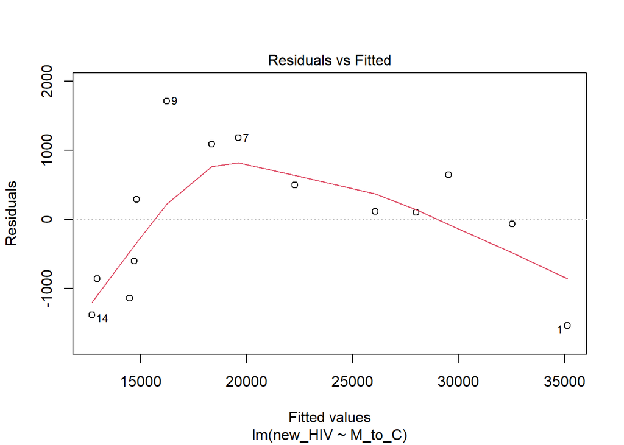

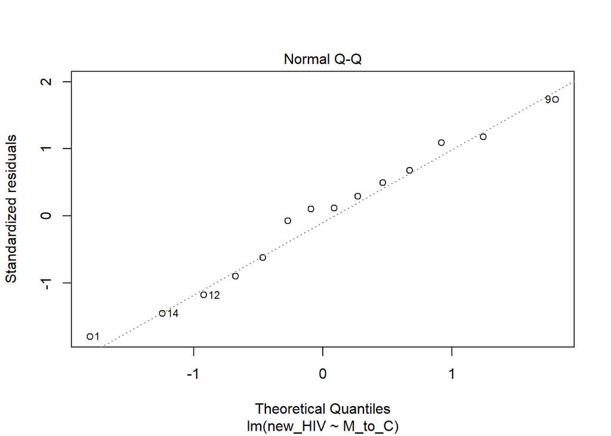

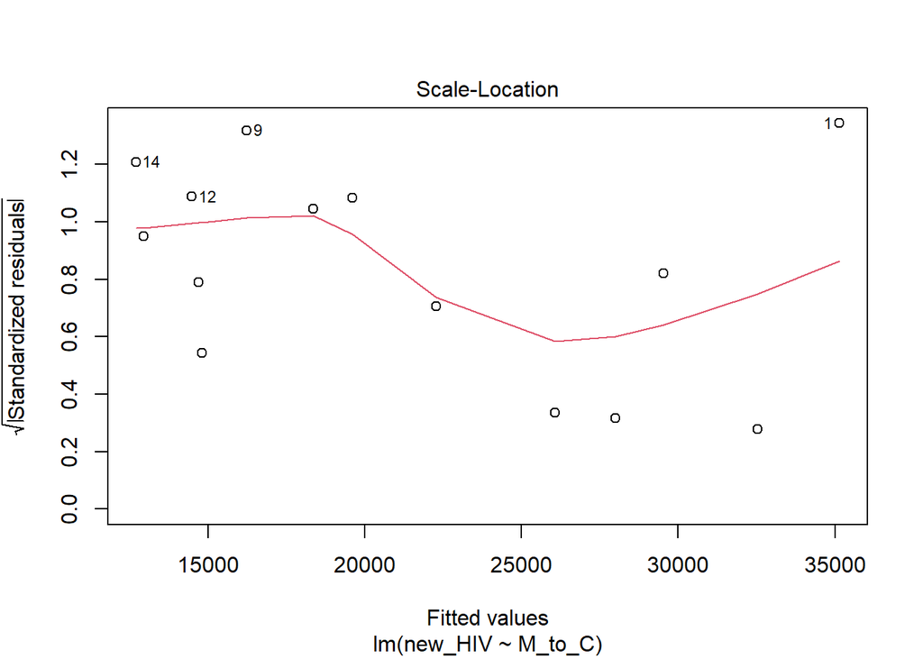

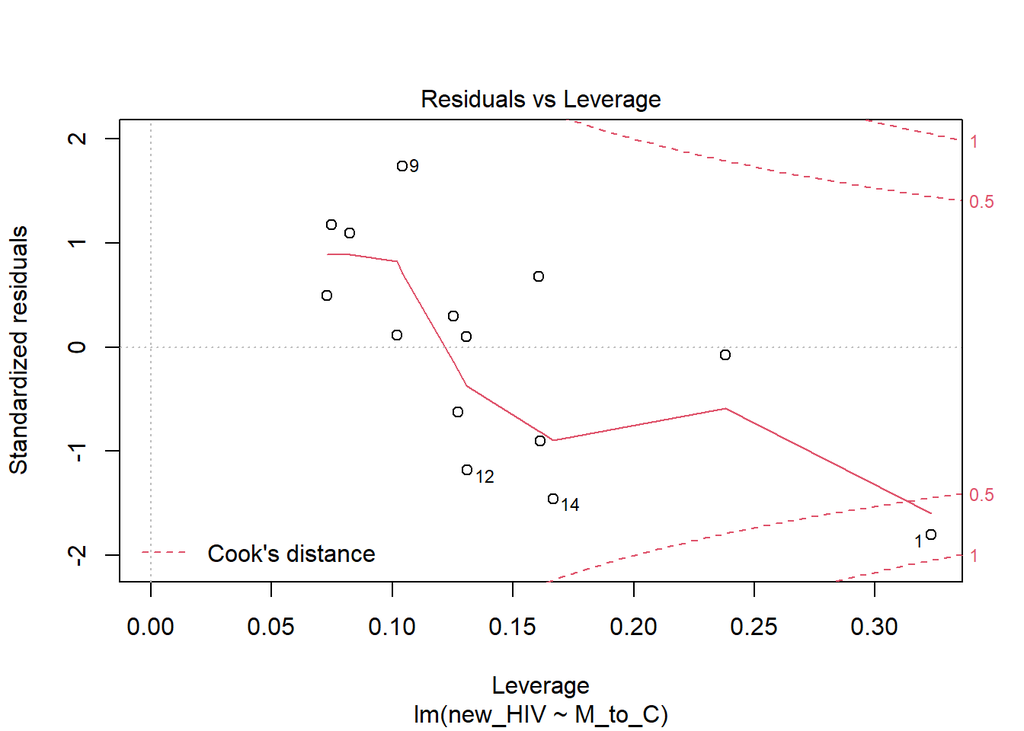

```r
#Diagnostic Test ----
m1 <- lm(new_HIV~ M_to_C, data=Plot_ready)

#Plot
m2 <- plot(m1, id.n=4)
```

```r
#shapiro.test(Plot_ready$new_HIV) # => p = 0.1532
#shapiro.test(Plot_ready$M_to_C) # => p = 0.08411
```

##### Pearson-Correlation Plots

To understand whether there is a positive correlation between Mother-to-child transmission rates and the number of new HIV cases, I plotted a scatter graph with pearson-correlation and the associated p-value. From this data there seems to be a clear positive correlation and a significant p-value associated with this data. This does suggest that we can reject the null hypothesis.

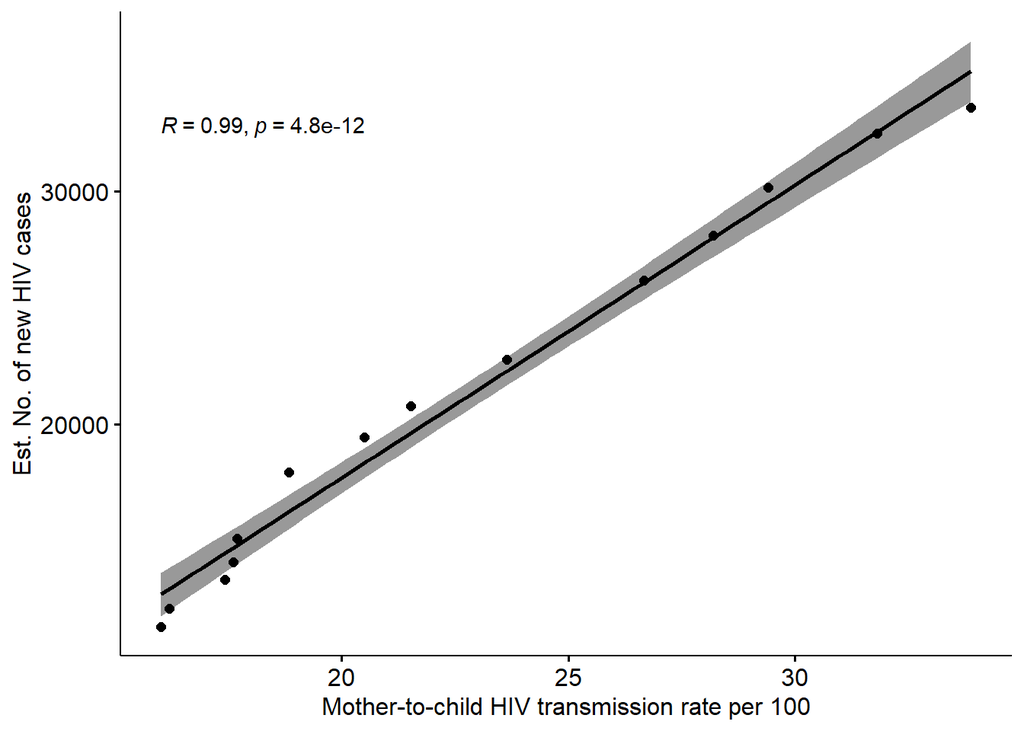

```r
#Correlation test ----

plot <- ggscatter(Plot_ready, x = "M_to_C", y = "new_HIV",
                  add = "reg.line", conf.int = TRUE,
                  cor.coef = TRUE, cor.method = "pearson", xlab = "Mother-to-child HIV transmission rate per 100", ylab = "Est. No. of new HIV cases"); plot
```

##### Comapring Males to Females using emmeans

To study whether there is a difference in the correlation above w.r.t. Sex, I used the emmeans package and took into account sex based difference in the data. The lack of overlap with the confidence intervals around the two means alone indicate a significant different between the two groups, with the females being nearly double to that of the male data.

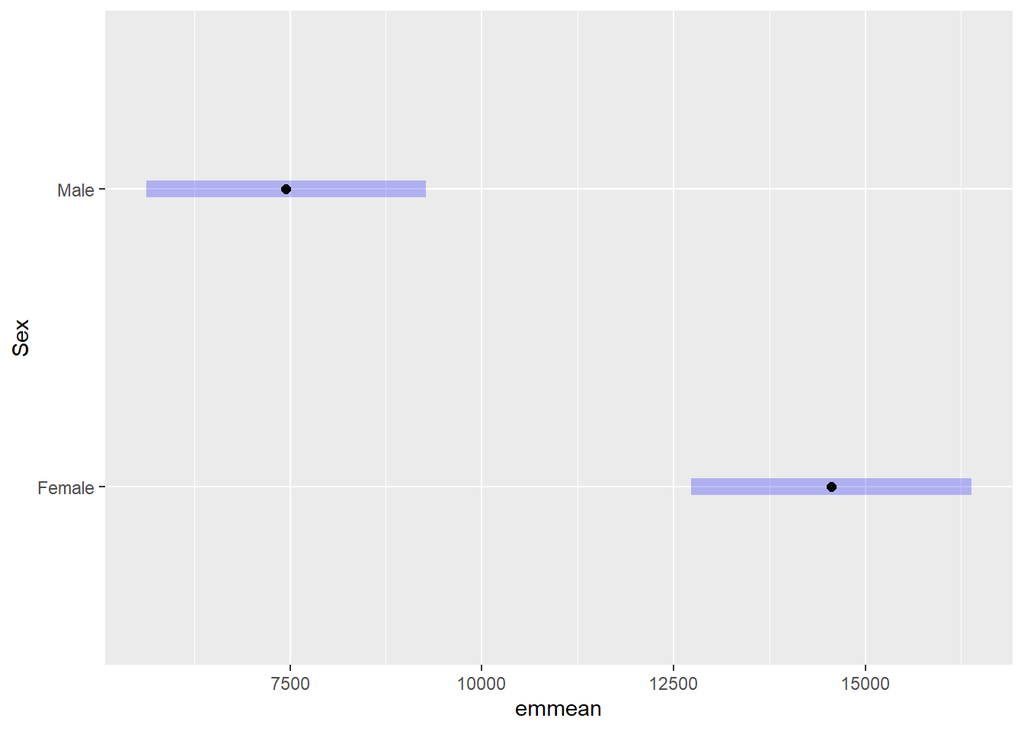

```r
#emmeans pairwise comparison on the bases of sex ----

lmboth <- lm(new_HIV~M_to_C + Sex, data=Plot_ready_S)
e1 <- emmeans(lmboth, "Sex")
p <- plot(e1); p
```